# Coding Assignment 2 (Part II) for Sergio Becerra

Fall 2021

```r
library(glmnet)
library(pls)
set.seed(5933) # change the seed to be the last 4-dig of your UIN
```

## Data Preparation

```r
myData = read.csv("~/Desktop/BostonData2.csv")
myData = myData[, -1]
bos3 = read.csv("~/Desktop/BostonData3.csv")
bos3 = bos3[, -1]
#names(myData)
```

Some algorithms need the matrix/vector input (instead of a data frame). Here the X matrix is loaded (3 subscripts are for the boston3 dataset)

```r
X = data.matrix(myData[,-1])
Y = myData[,1]
X3 = data.matrix(bos3[,-1])
Y3 = bos3[,1]
```

We will repeat the following simulation 50 times. In each iteration, randomly split the data into two parts, 75% for training and 25% for testing.

You can write a loop with 50 iterations, and in each iteration, split the data and run the seven procedures (six procedures for `BostonData3.csv`).

Or you can save the row IDs for the 50 test datasets, then write a separate loop for each method. Using `all.test.id` (produced below), you can ensure that you use the same training/test split for each procedure.

```r
T = 50
n = length(Y)
ntest = round(n * 0.25)  # test set size
ntrain = n - ntest  # training set size
all.test.id = matrix(0, ntest, T)  #
for(t in 1:T){
  all.test.id[, t] = sample(1:n, ntest)
}
#save(all.test.id, file="alltestID.RData")
```

## Simulation

first creating a MSPE matrix for Boston2 data and Boston3 data.

```r
mspe=matrix(0, 7, T)
mspe3=matrix(0, 6, T)

names(mspe) = c("Full", "R_min", "R_1se", "L_min", "L_1se", "L_Refit", "PCR")
names(mspe3) = c("R_min", "R_1se", "L_min", "L_1se", "L_Refit", "PCR")
```

### Full Model

Running the full model on Boston 2:

```r
for(t in 1:T){
  test.id = all.test.id[,t]
  full.model = lm(Y ~ ., data = myData[-test.id,])
  Ytest.pred = predict(full.model, newdata = myData[test.id,])
  mspe[1,t] = mean((myData$Y[test.id] - Ytest.pred)^2)

}
```

### Ridge

Ridge from code provided.

```r
cv.out = cv.glmnet(X[-test.id, ], Y[-test.id], alpha = 0)
best.lam = cv.out$lambda.min
```

The output below is zero, which means that `best.lam` is the smallest lambda value in the default lambda sequence used by `cv.glmnet`. If so, we need to include some lambda values that are smaller than `best.lam` in order to see the U shape CV plot.

```r
sum(cv.out$lambda < best.lam)
```

```
## [1] 0
```

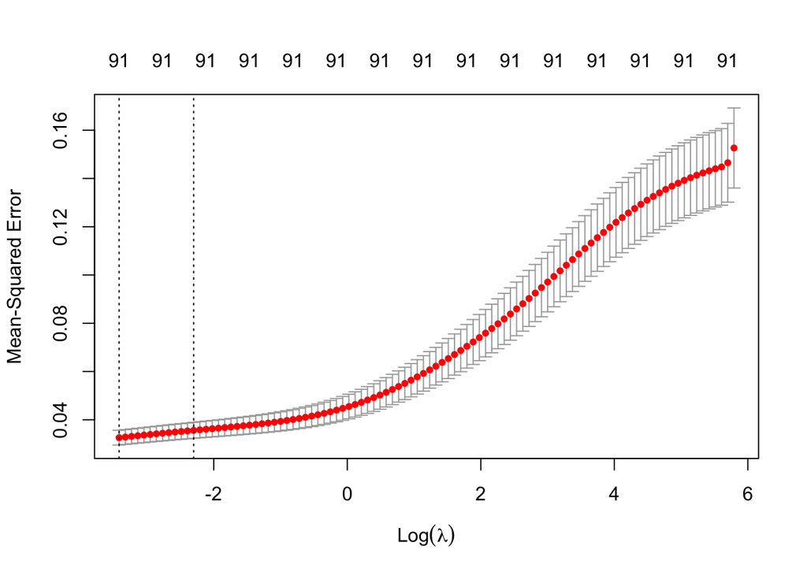

```r
plot(cv.out)
```

Based on the CV plot, we provide a new lambda sequence as follows.

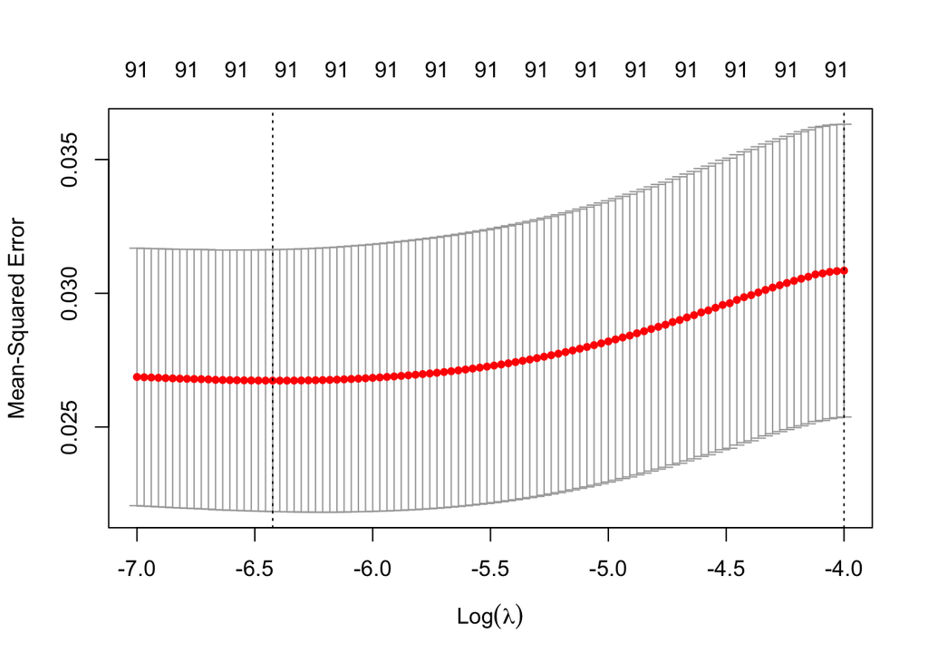

```r
#the following is the lambda sequence for boston data 2
lambda.b2 = exp(seq(-7, -4, length.out = 100))
cv.out = cv.glmnet(X[-test.id, ], Y[-test.id], alpha = 0,
                   lambda = lambda.b2)
plot(cv.out)
```

Based on the CV plot, we have to keep decreasing lambda values. Eventually, we use the following lambda sequence for our full simulation.

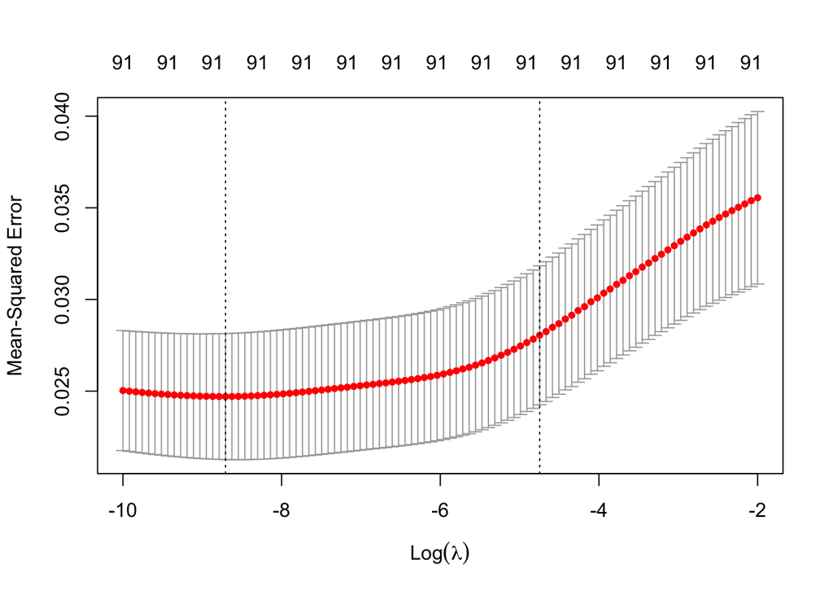

```r
lambda.b2 = exp(seq(-10, -2, length.out = 100))
cv.out = cv.glmnet(X[-test.id, ], Y[-test.id], alpha = 0,
                   lambda = lambda.b2)
plot(cv.out)
```

For the boston 3 data we will be using the following Lamda sequence for our simulation:

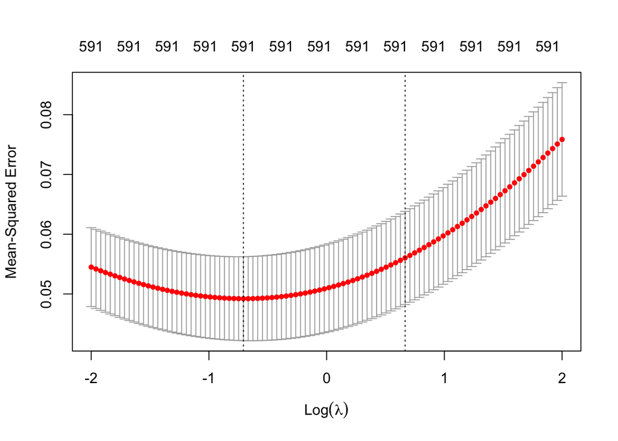

```r
lambda.b3 = exp(seq(-2, 2, length.out = 100))
cv.out = cv.glmnet(X3[-test.id, ], Y3[-test.id], alpha = 0,lambda = lambda.b3 )
plot(cv.out)
```

### Lasso

Lasso to confirm lambda sequence

```r
cv.out = cv.glmnet(X[-test.id, ], Y[-test.id], alpha = 1)
```

The CV plot indicates that the default lambda sequence for Lasso seems fine.

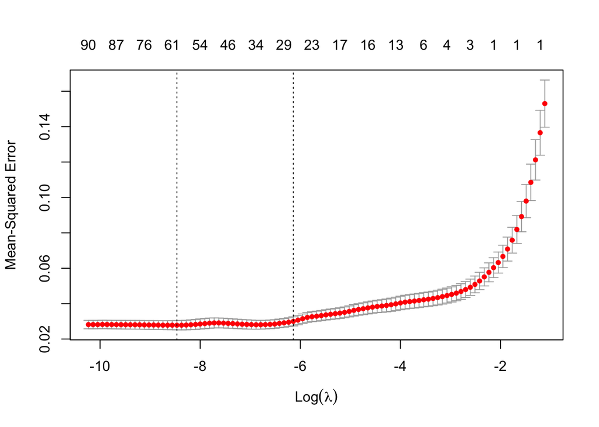

```r
plot(cv.out)
```

..and for boston 3

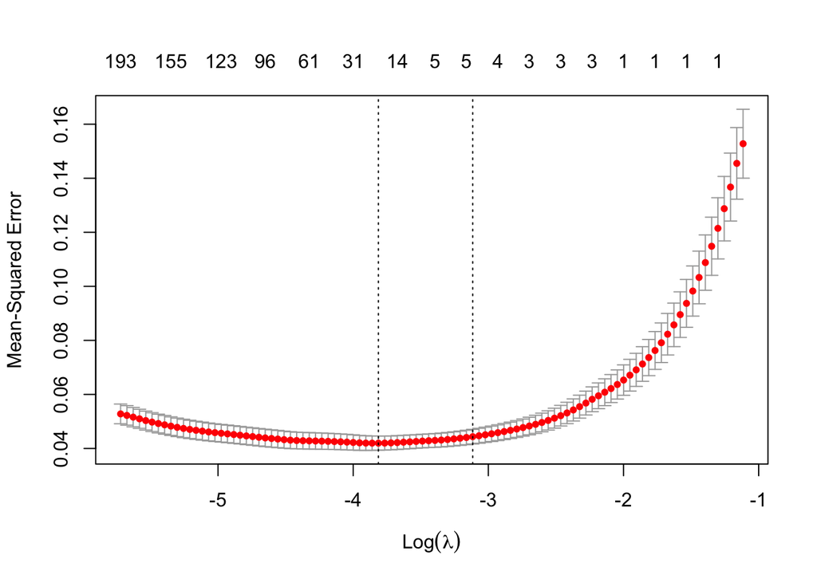

```r
cv.out = cv.glmnet(X3[-test.id, ], Y3[-test.id], alpha = 1)
plot(cv.out)
```

```r
#simulation loop
for(t in 1:T){
  test.id = all.test.id[,t]
  #ridge on Boston 2
  cv.out = cv.glmnet(X[-test.id, ], Y[-test.id], alpha = 0,
                   lambda = lambda.b2)
  best.lam = cv.out$lambda.min
  Ytest.pred = predict(cv.out, s = best.lam, newx = X[test.id, ])
  mspe[2,t] = mean((Y[test.id] - Ytest.pred)^2)

  best.lam = cv.out$lambda.1se
  Ytest.pred = predict(cv.out, s = best.lam, newx = X[test.id, ])
  mspe[3,t] = mean((Y[test.id] - Ytest.pred)^2)
  #ridge on Boston 3
  cv.out = cv.glmnet(X3[-test.id, ], Y3[-test.id], alpha = 0,
                   lambda = lambda.b3)
  best.lam = cv.out$lambda.min
  Ytest.pred = predict(cv.out, s = best.lam, newx = X3[test.id, ])
  mspe3[1,t] = mean((Y3[test.id] - Ytest.pred)^2)

  best.lam = cv.out$lambda.1se
  Ytest.pred = predict(cv.out, s = best.lam, newx = X3[test.id, ])
  mspe3[2,t] = mean((Y3[test.id] - Ytest.pred)^2)

  #lasso on Boston 2
  cv.out = cv.glmnet(X[-test.id, ], Y[-test.id], alpha = 1)
  best.lam = cv.out$lambda.min
  Ytest.pred = predict(cv.out, s = best.lam, newx = X[test.id, ])
  mspe[4,t] = mean((Y[test.id] - Ytest.pred)^2)

  best.lam = cv.out$lambda.1se
  Ytest.pred = predict(cv.out, s = best.lam, newx = X[test.id, ])
  mspe[5,t] = mean((Y[test.id] - Ytest.pred)^2)

  mylasso.coef = predict(cv.out, s = best.lam, type = "coefficients")
  var.sel = row.names(mylasso.coef)[which(mylasso.coef != 0)[-1]]
  mylasso.refit = lm(Y ~ ., myData[-test.id, c("Y", var.sel)])
  Ytest.pred = predict(mylasso.refit, newdata = myData[test.id, ])
  mspe[6,t] = mean((Ytest.pred - Y[test.id])^2)

  #lasso on Boston 3
  cv.out = cv.glmnet(X3[-test.id, ], Y3[-test.id], alpha = 1)
  best.lam = cv.out$lambda.min
  Ytest.pred = predict(cv.out, s = best.lam, newx = X3[test.id, ])
  mspe3[3,t] = mean((Y3[test.id] - Ytest.pred)^2)

  best.lam = cv.out$lambda.1se
  Ytest.pred = predict(cv.out, s = best.lam, newx = X3[test.id, ])
  mspe3[4,t] = mean((Y3[test.id] - Ytest.pred)^2)

  mylasso.coef = predict(cv.out, s = best.lam, type = "coefficients")
  var.sel = row.names(mylasso.coef)[which(mylasso.coef != 0)[-1]]
  mylasso.refit = lm(Y ~ ., bos3[-test.id, c("Y", var.sel)])
  Ytest.pred = predict(mylasso.refit, newdata = bos3[test.id, ])
  mspe3[5,t] = mean((Ytest.pred - Y3[test.id])^2)

  #pcr on Boston 2
  mypcr = pcr(Y ~ ., data= myData[-test.id, ], validation="CV")
  CVerr = RMSEP(mypcr)$val[1, , ]
  adjCVerr = RMSEP(mypcr)$val[2, , ]
  best.ncomp = which.min(CVerr) - 1
  best.ncomp

  if (best.ncomp==0) {
      Ytest.pred = mean(myData$Y[-test.id])
    } else {
      Ytest.pred = predict(mypcr, myData[test.id,], ncomp=best.ncomp)
    }

  mspe[7,t] = mean((Ytest.pred - myData$Y[test.id])^2)

  #pcr on Boston 3
  mypcr = pcr(Y ~ ., data= bos3[-test.id, ], validation="CV")
  CVerr = RMSEP(mypcr)$val[1, , ]
  adjCVerr = RMSEP(mypcr)$val[2, , ]
  best.ncomp = which.min(CVerr) - 1
  best.ncomp

  if (best.ncomp==0) {
      Ytest.pred = mean(bos3$Y[-test.id])
    } else {
      Ytest.pred = predict(mypcr, bos3[test.id,], ncomp=best.ncomp)
    }

  mspe3[6,t] = mean((Ytest.pred - bos3$Y[test.id])^2)
}
```

## Results

Now we present the two simulations results for Boston 2 and Boston 3 datasets. The PCR result perormed markedly worse relative to its competitors in Boston 3 dataset.

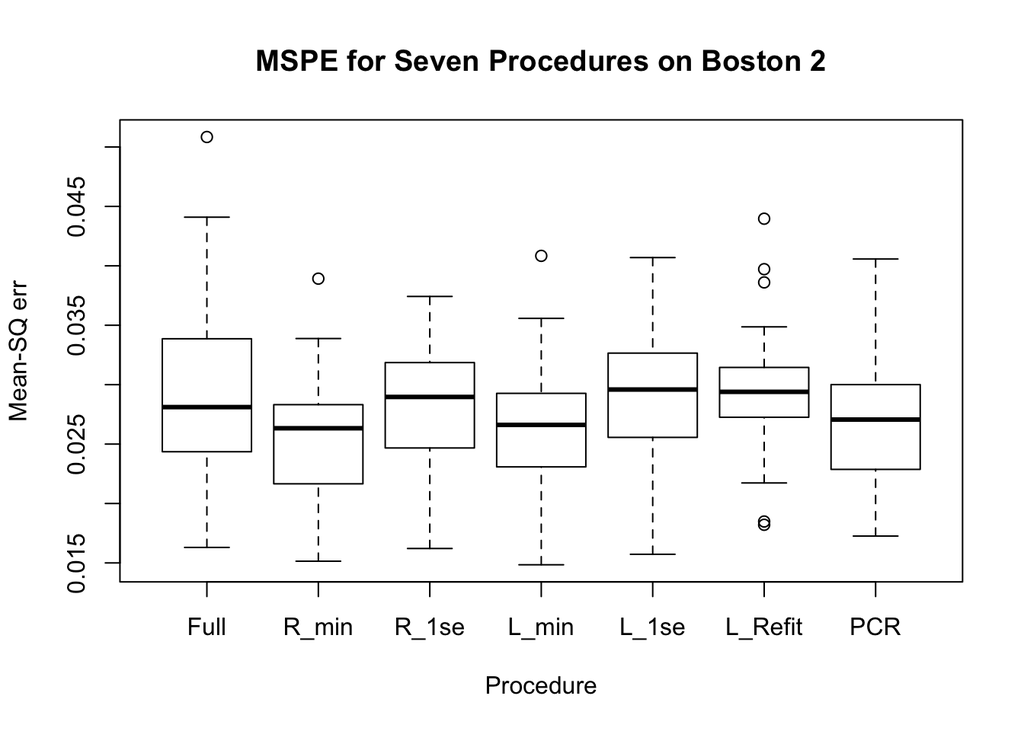

```r
boxplot.matrix(mspe,use.cols = FALSE,main="MSPE for Seven Procedures on Boston 2",
   xlab="Procedure", ylab="Mean-SQ err",names= c("Full", "R_min", "R_1se", "L_min", "L_1se", "L_Refit", "PCR"))
```

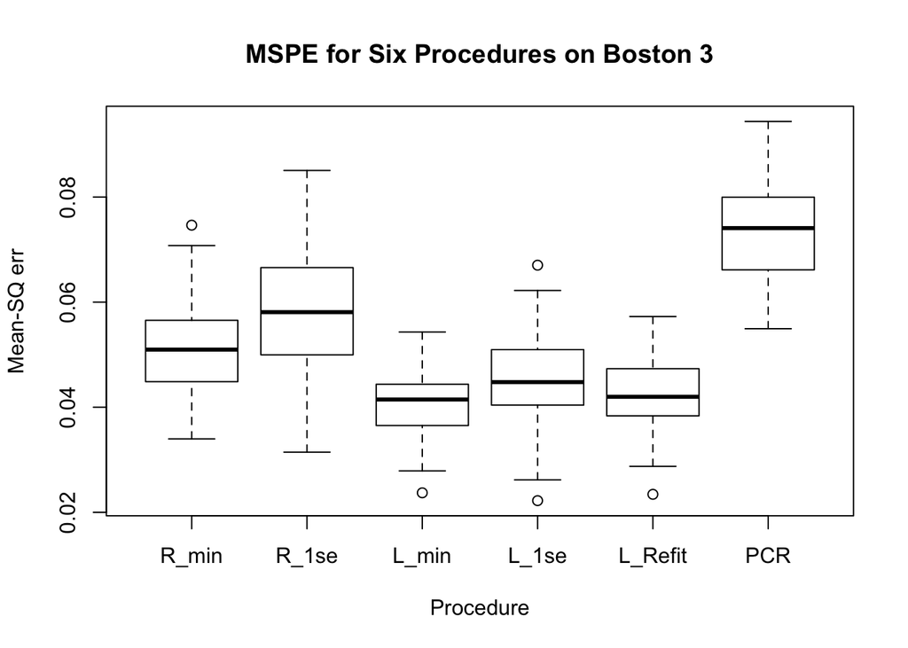

```r
boxplot.matrix(mspe3,use.cols = FALSE,main="MSPE for Six Procedures on Boston 3",
   xlab="Procedure", ylab="Mean-SQ err",names= c( "R_min", "R_1se", "L_min", "L_1se", "L_Refit", "PCR"))
```